# Multivariate Analysis

#### Talk about some of the relationships you observed in this part of the investigation. Were there features that strengthened each other in terms of looking at your feature(s) of interest?

When the data was restricted to conditions proposed to be successful in applying for a loan with Prosper the results of the shift across all observations becomes much clearer. Furthermore, when we restrict the conditions closer to what is ideal, it is then that we can see a much more significant change in the data.

#### Were there any interesting or surprising interactions between features?

The relationship between DTI and Current credit lines was really interesting. When setting a conditional scope to observe correlation changes at first I was surprised to see such a dramatic change. I hadn’t truly considered the impact on the relationship between the two variables.

# Final Plots and Summary

### Plot One

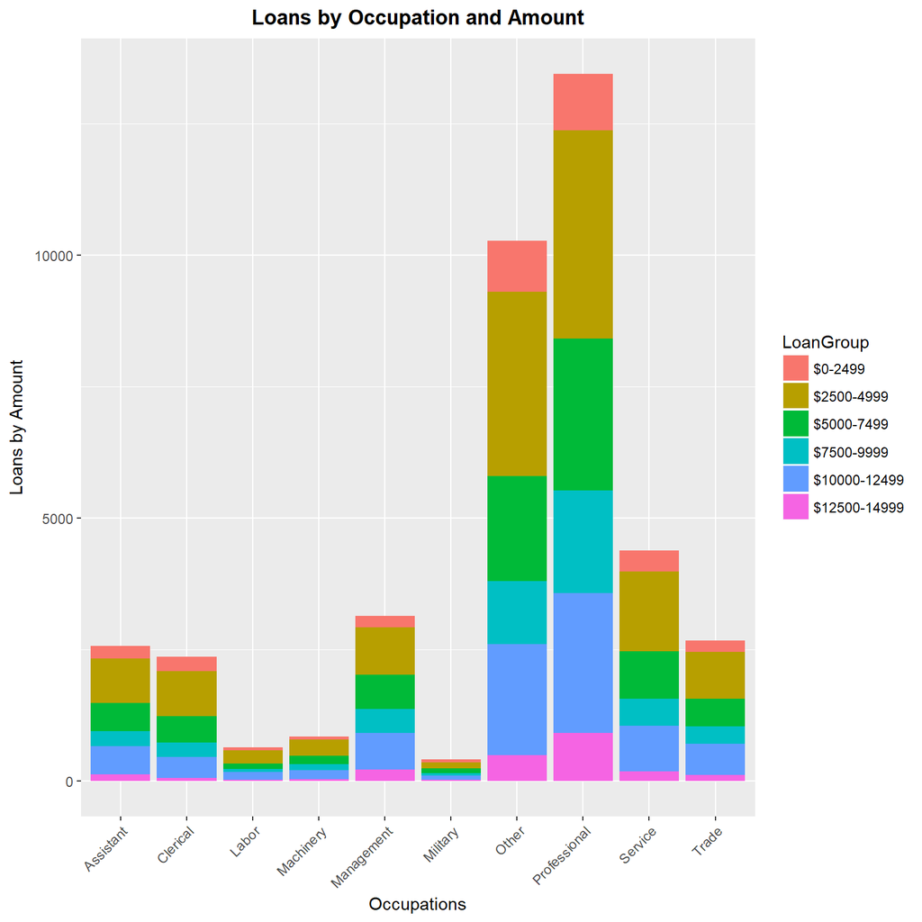

### Plot Two

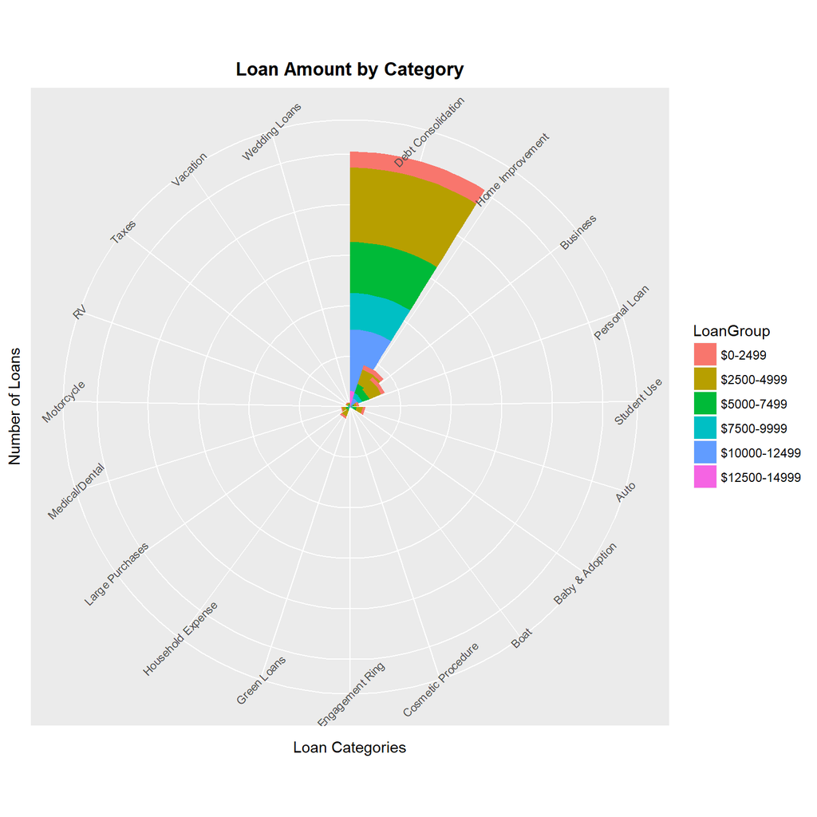

### Description Two

This plot was chosen to answer the questions of what(loan amount), and why(loan category). We know the answer to the who of Prosper loans this plot shows that we will be more successful in the loan application process if the loan is for debt consolidation. However, if the loan is for home improvement or business and the amount requested is less than $7,500 we will be much more likely to be approved than for other loan categories.

### Plot Three

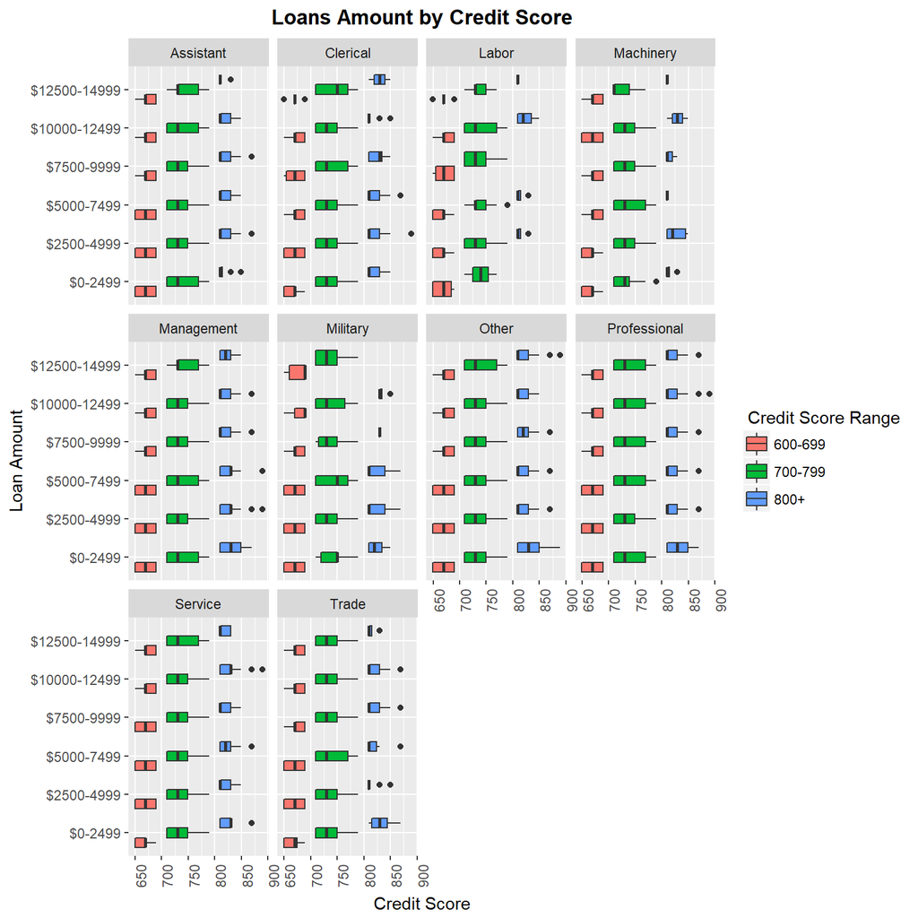

### Description Three

#### Reflection

The goal of this study was to answer the questions of who, what, why and how Prosper grants loans. The dataset used holds 113,937 entries across 81 variables. The total number of variables used across this study both original and created totaled 26.

The choice of those specific variables was made to give the most meaning to the data by using a more traditional approach to the criteria of the loan process.

From there each was evaluated parallel to the goals of the study.  
I was able to determine that while certain occupations have a higher volume of loans, all occupations were represented if they were within the parameters that were defined as preferred.

**The final preferred criteria is:**

- All Occupations
- Credit Score >= 650
- Current Delinquencies < 1
- Debt to Income Ratio < .30
- Income > $25,000
- Loan Amount < $15,000
- Loan Category of Debt Consolidation, Business or Home Improvement

There are so many more insights to be gained from this data set and I have just scratched the surface. Other things to explore could be how Prosper defines a good risk or how many of Propser’s customers are repeat customers. It would also be interesting to take this data and develop a model to help investors determine the best loans to back and what loans to avoid.

#### Sources

- [ISCO](https://en.wikipedia.org/wiki/International_Standard_Classification_of_Occupations)
- [Prosper Loan Types](https://www.prosper.com/plp/loans/loan-types/)
- [Apostrophes in R](http://r.789695.n4.nabble.com/Apostrophes-in-R-Commander-in-recode-td3704453.html)
- [Factors](https://www.stat.berkeley.edu/classes/s133/factors.html)
- [S&P 500](https://www.cnbc.com/quotes/?symbol=.SPX)